# Proyecto: Pronósticos y Clustering

Dimas Ramirez Luis Daniel

25/03/2023

# Análisis de la situación del negocio

Uno de los servicios que ofrece Nielsen a sus clientes, es la medición de audiencias. Para que Nielsen pueda realizar esas mediciones, tiene una muestra representativa de casas que eligen voluntariamente participar dentro de la medición. La medición se realiza a través de un dispositivo llamado **TV meter** el cual es instalado por un técnico de Nielsen en cada television dle domicilio. Este dispositivo se encuentra en cada casa para que los integrantes de ese domicilio puedan usarlo cada vez que encienden su televisión, de esa manera el TV Meter de manera simultanea comienza a recopilar la información.

La recopilación total que el TV Meter registra se conoce como INTAB. El INTAB es un indicador que nos permite saber el % de información total que se recopilo y el complemento corresponde a la información que por alguna razón esta dañanada o no se pudo recopilar.

El INTAB de una casa es importante debido a que si hay un INTAB muy bajo para un domicilio, el análisis posterior de la audiencia tiene un porcentaje de error. Tal vez, si sólo es un casa el problema no es grave, sin embargo cuando varios domicilios tienen un INTAB bajo, los análisis de audiencia que se entregan a los clientes (televisoras) está sesgado debido al error generado por la mala recopilación de la información a través de los TV Meters.

Por esa razón es que el INTAB es crucial para poder entregar un buen análisis. Cuando hay un INTAB bajo, NIELSEN contacta al responsable registrado de ese domicilio para averiguar si el INTAB bajo se debe a un mal uso del TV Meter o si hay un error técnico en el aparato. De esa manera se puede arreglar via telfónica o a veces es necesario la visita de un técnico para diagnosticar y arreglar el problema.

Se cuenta con la información de los INTAB promedio por semana de los domicilios, sin embargo son datos que recientemente se incorporaron a la base de datos de Nielsen, por lo tanto son pocos. Se cuenta con información semanal a partir de Septiembre-2022.

# Objetivo

El objetivo con este proyecto es realizar el pronóstico de INTAB para dos semanas adelante y clasificar en grupos los domicilios. De esa manera se puede tener una idea de como va a estar el promedio general y dar un seguimiento más cercano a los domicilios que suelen tener un INTAB bajo.

Las conclusiones de este proyecto se complementara (más adelante una vez que tenga la validación de mi manager) con una visualización dinámica en Google Data Studio la cual contendra el pronóstico para cada domicilio, de esa manera los encargados de esta parte en NIELSEN, podrán seguir detalladamente si alguno de los domicilios seguira teniendo un INTAB bajo o si su pronóstico va a la alza. Esta visualización se hara más adelante y con más tiempo para poder implementarla de manera oficial.

# Hipótesis

1- El mejor pronóstico lo podré encontrar con un modelo ARIMA

2- Los datos se pueden clasificar de manera óptima en 2 clusters

# Limpieza/transformación y análisis descriptivo de datos

Importación de la data

Despues de haber importado los datos, los convertiré en una serie de tiempo y observare su comportamiento general:

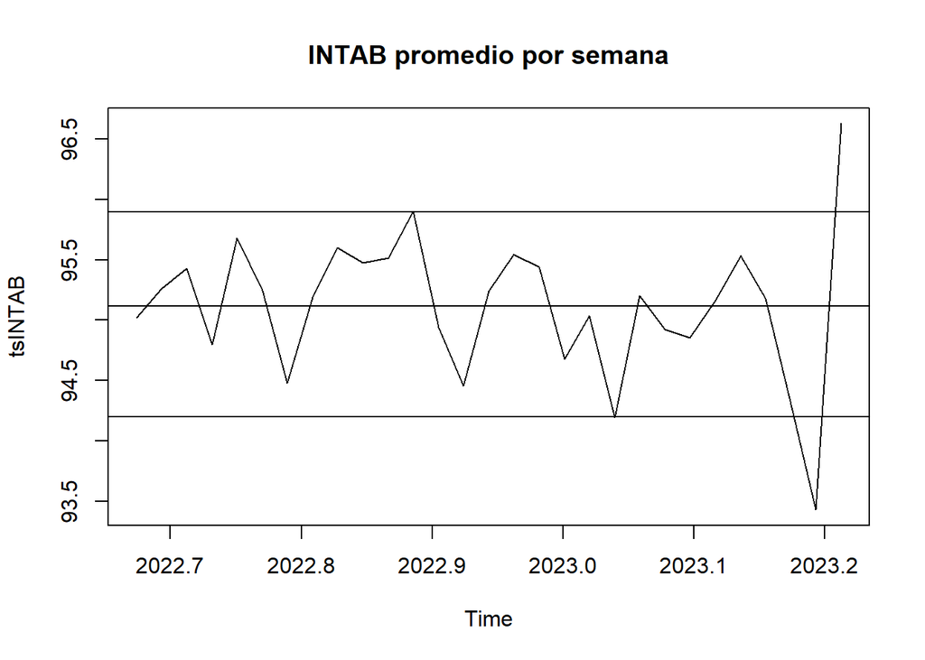

Recordando los conceptos para poder trabajar con series de tiempo…

- Para poder hacer pronósticos necesitamos que nuestra serie de tiempo sea estacionaria (media nula o constante, varianza constante) y que no haya tendencia
- La serie tiene qu estar autocorrelacionada (no tiene media nula pero si constante y es estacionaria )

Una de las técnicas más comunes que se utilizan para poder estabilizar las series de tiempo es la de las diferencias. Con la siguiente función voy a darme una idea si mi serie de tiempo se necesita diferenciar, y si sí, cuantas veces:

```r
ndiffs(tsINTAB) # No se necesita diferenciar
```

```
## [1] 0
```

Aunque al parecer no es necesario diferenciar la serie de tiempo, realizaré la diferencia y haré una compraracion entre la serie diferenciada y la serie original.

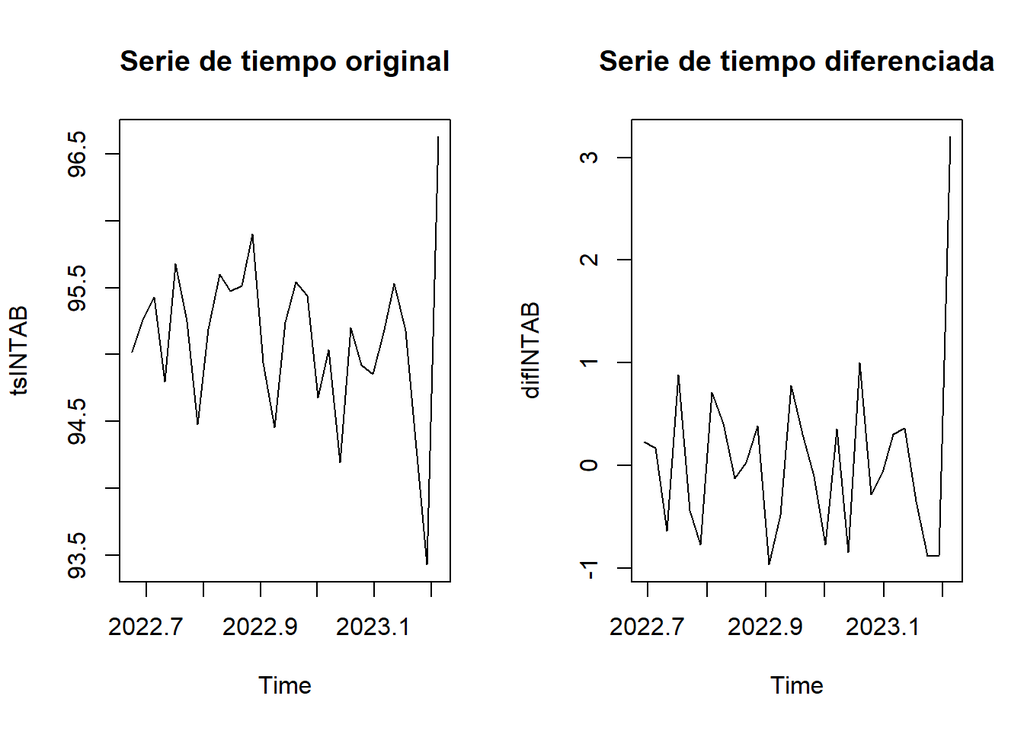

A grandes rasgos, de la gráfica anterior puedo notar que el comportamiento de la serie no cambio, se estabilizo porque la media ahora en efecto es nula, sin embargo el comportamiento es el mismo. Por eso es que anteriormente la función estadística me dio como resultado que no necesitaba diferenciarse la serie de tiempo.

Para poder ver si hay alguna diferencia más; la varianza de la serie de tiempo orginial es de 0.3582061 mientras que la varianza de la serie diferenciada es de 0.7154106.

Al comparar las varianzas entre la serie de tiempo original y la diferenciada puedo observar que la varianza de la serie original es casi la mitad que la de la varianza diferenciada. Por lo tanto utilizaré mejor la serie original.

Para intentar estabilizar un poco más la varianza que de por si ya es pequeña, utilizare el metodo de logaritmo natural en la serie de tiempo original. De tal manera que ahora la serie de tiempo, ya estabilizada queda de la siguiente manera:

De esta manera la varianza se reduce a 3.9692087^{-5}

Una vez que nuestra serie de tiempo ya se encuentra lista, procederé a revisar las graficas de Autocorrelacion y Autocorrelacion parcial para empezar a probar con nuestro primero modelo que sera el **ARIMA**.

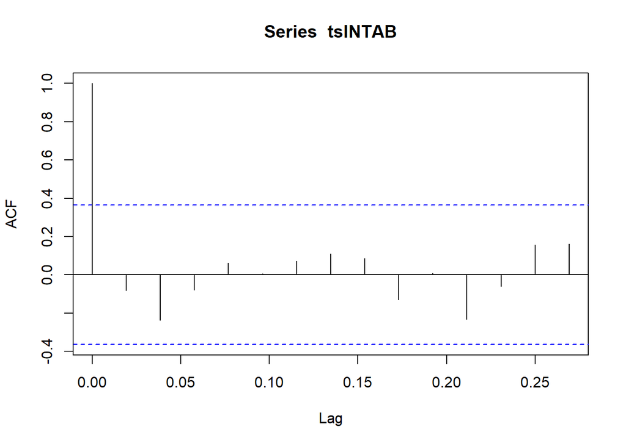

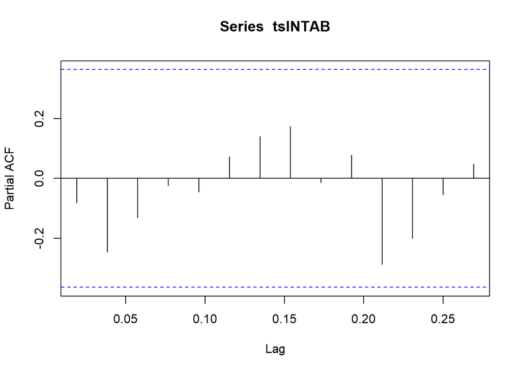

## Selección de modelos analíticos

### ARIMA con la serie original

Autoregressive Integrated Moving Averages. Los pronósticos ARIMA se hacen con series de tiempo estacionarias. ARIMA(p,d,q)

- AR (auto-regressive): p
- MA (moving averages): q
- Number of differences: d

p - ACF: la autocorrelación es una medida de correlación ente la serie de tiempo con la serie de tiempo con rezago. La variable q se define como el número de veces que la serie de tiempo rompe los intervalos de confianza superiores .

q - PACF: la autocorrelación parcial es una medida de correlación entre la serie de tiempo con la serie de tiempo con rezago pero después de eliminar las variaciones. La variable q se define como el número de veces que la serie de tiempo rompe los intervalos de confianza superiores.

```r
modelo_arima <- auto.arima(tsINTAB, stepwise = FALSE, approximation = FALSE, trace=F, nmodels=2000)
summary(modelo_arima)
```

```
## Series: tsINTAB
## ARIMA(0,0,0) with non-zero mean
##
## Coefficients:
##         mean
##       4.5551
## s.e.  0.0012
##
## sigma^2 = 3.969e-05:  log likelihood = 106.31
## AIC=-208.62   AICc=-208.15   BIC=-205.88
##
## Training set error measures:
##                         ME        RMSE         MAE           MPE    MAPE MASE
## Training set -1.148507e-14 0.006190589 0.004554399 -0.0001848065 0.10001  NaN
##                     ACF1
## Training set -0.08126681
```

El mejor modelo según la funcion, no es el modelo propuesto por mi que es un ARIMA(1,0,0). Es un modelo ARIMA(0,0,0).

Sin embargo un modelo teórico ARIMA(0, **d** ,0) es una serie que se convierte en ruido blanco (proceso puramente aleatorio) después de ser diferenciada **d** veces. Por lo tanto este metódo de pronóstico no seria el mejor. Verificando lo dicho anteriormente, haré la siguiente prueba de ruido blanco.

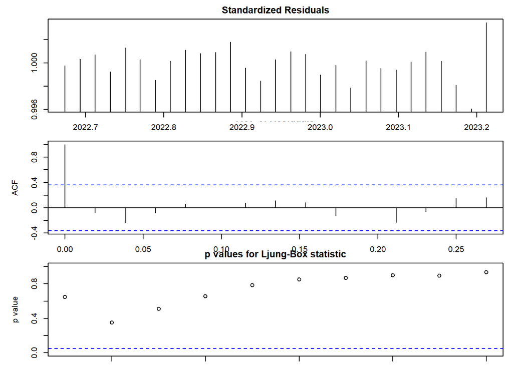

De la anterior gráfica, concentrandonos en los p values observamos que todos los p values son mayores a 0.05, por lo tanto nos evidencia que nuestro modelo; estadisticamente no es malo. Si alguno o todos los p values fueran menores a 0.05 nuestro modelo no se ajustaria bien.

Aunque la prueba de p values para la estadÍstica Ljung Box nos muestra que el modelo no es malo, sabemos que un modelo ARIMA(0,0,0) nos dice que la historia de los datos no brinda ninguna información. Por lo tanto queda descartado este modelo de pronostico para nuestros datos.

## Otras técnicas de pronóstico

Para realizar nuestra validación del pronostico separaremos nuestro data set en dos partes, la de entrenamiento y la de validación.

Los datos de entrenamiento serán los primeros 28 datos, mientras que validaremos con le ultimo dato.

Para hacer más simple la iteracion, cree una funcion con la cual solamente le indicare el numero de periodos n que toma en cuenta el promedio movil.

### Promedio Móvil Simple

Es el procedimiento más simple y consiste en obtener la media aritmetica, la cual es el pronostico para el siguiente periodo. Es apropiado cuando la serie es estacionaria aunque su media no es nula pero sí constante al igual que su varianza

#### Promedio móvil simple con N=2

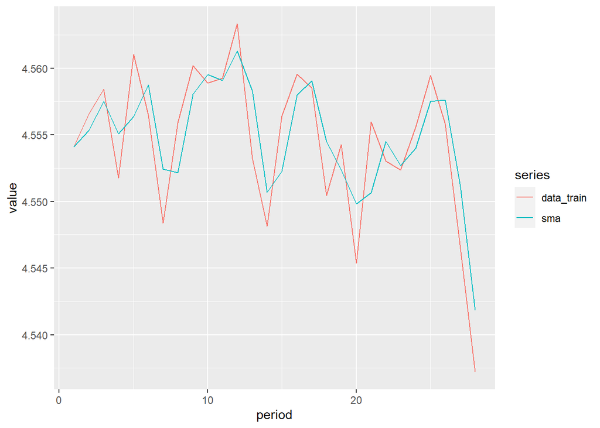

```
##    Point Forecast   Lo 80    Hi 80   Lo 95    Hi 95
## 29        4.55212 4.54683 4.557411 4.54403 4.560211
## [1] "MAE=0.00254047611733361"
## [1] "MAPE=0.000557914422078142"
## [1] "SMAPE=0.000557954026058926"
## [1] "MSE=9.082339207443e-06"
## [1] "RMSE=0.00301369195629597"
```

#### Promedio móvil simple con N=3

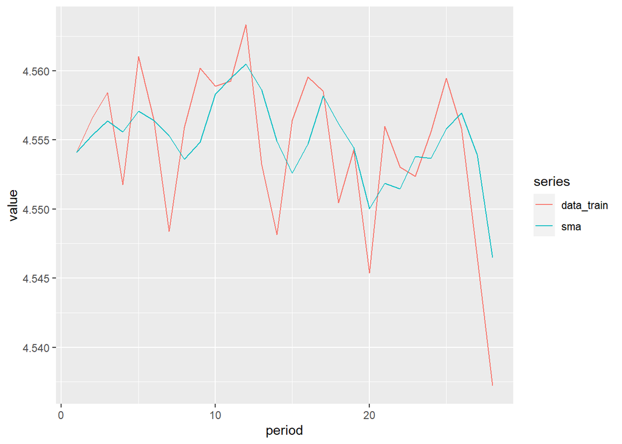

```
##    Point Forecast    Lo 80    Hi 80   Lo 95    Hi 95
## 29        4.54649 4.543208 4.549773 4.54147 4.551511
## [1] "MAE=0.00326947704295504"
## [1] "MAPE=0.000717919703975663"
## [1] "SMAPE=0.000718090554445661"
## [1] "MSE=1.69502440484723e-05"
## [1] "RMSE=0.00411706740878411"
```

#### Promedio móvil simple con N=4

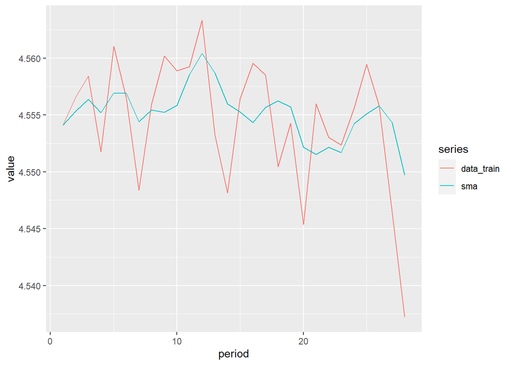

```
##    Point Forecast    Lo 80    Hi 80    Lo 95    Hi 95
## 29       4.549729 4.547424 4.552033 4.546204 4.553253
## [1] "MAE=0.00349972713190312"
## [1] "MAPE=0.000768404752034687"
## [1] "SMAPE=0.000768660269692892"
## [1] "MSE=2.08441731248796e-05"
## [1] "RMSE=0.00456554193112708"
```

#### Promedio móvil simple con N=5

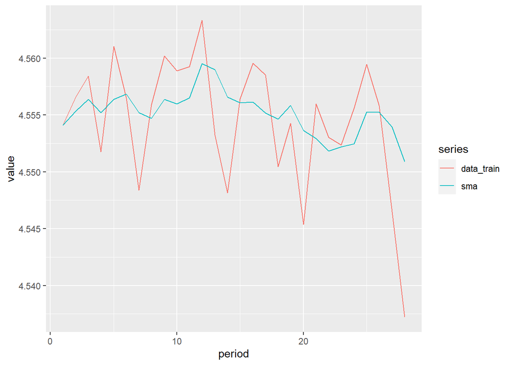

```
##    Point Forecast    Lo 80    Hi 80    Lo 95    Hi 95
## 29       4.550904 4.549036 4.552773 4.548047 4.553762
## [1] "MAE=0.00363540442710415"
## [1] "MAPE=0.000798130876858376"
## [1] "SMAPE=0.000798440947796004"
## [1] "MSE=2.24786460777293e-05"
## [1] "RMSE=0.00474116505489202"
```

#### Promedio móvil simple con N=6

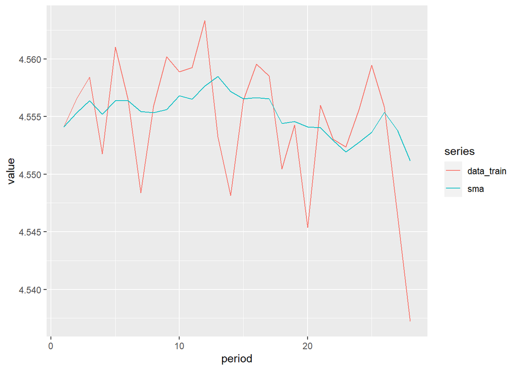

```
##    Point Forecast    Lo 80    Hi 80    Lo 95    Hi 95
## 29       4.551149 4.549708 4.552589 4.548945 4.553352
## [1] "MAE=0.00354424907273037"
## [1] "MAPE=0.000778109861689524"
## [1] "SMAPE=0.000778420145426832"
## [1] "MSE=2.36143321827805e-05"
## [1] "RMSE=0.00485945801327478"
```

#### Promedio móvil simple con N=7

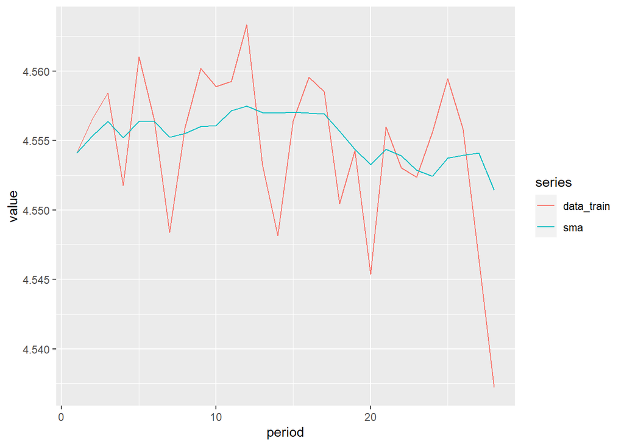

```
##    Point Forecast    Lo 80    Hi 80    Lo 95    Hi 95
## 29       4.551419 4.550175 4.552663 4.549516 4.553322
## [1] "MAE=0.00356553043369904"
## [1] "MAPE=0.000782798776975531"
## [1] "SMAPE=0.000783103824605021"
## [1] "MSE=2.32754037749904e-05"
## [1] "RMSE=0.00482445891007379"
```

#### Promedio móvil simple con N=8

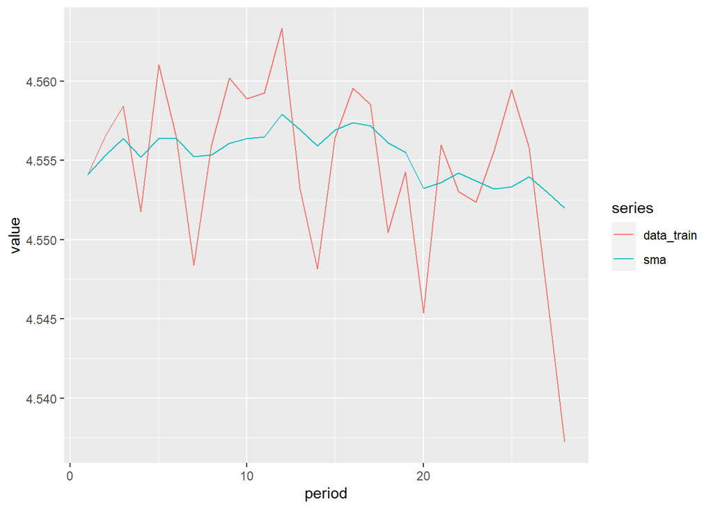

```
##    Point Forecast    Lo 80    Hi 80    Lo 95    Hi 95
## 29       4.551988 4.550795 4.553182 4.550163 4.553813
## [1] "MAE=0.00359015708730778"
## [1] "MAPE=0.000788219486917222"
## [1] "SMAPE=0.000788519114137294"
## [1] "MSE=2.28544520749239e-05"
## [1] "RMSE=0.00478063302031477"
```

#### Promedio móvil simple con N=9

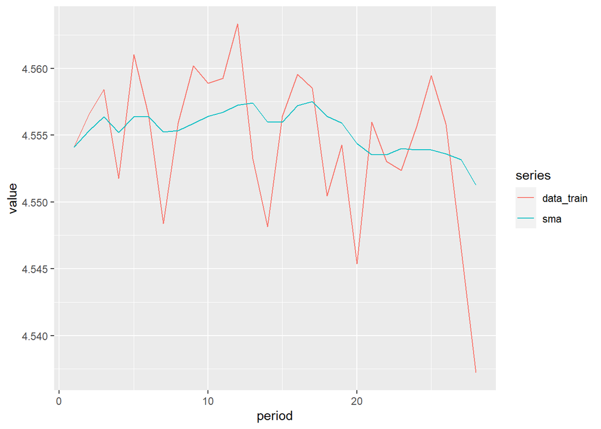

```
##    Point Forecast    Lo 80    Hi 80    Lo 95    Hi 95
## 29       4.551253 4.550135 4.552371 4.549543 4.552962
## [1] "MAE=0.00362402695909516"
## [1] "MAPE=0.000795639718484373"
## [1] "SMAPE=0.000795945944470665"
## [1] "MSE=2.31768058798387e-05"
## [1] "RMSE=0.00481422952089311"
```

#### Promedio móvil simple con N=10

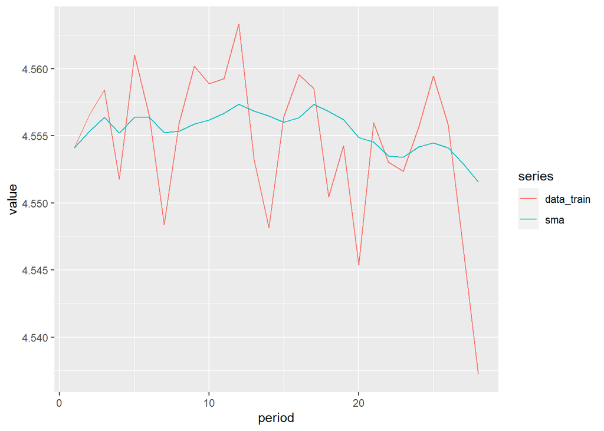

```
##    Point Forecast    Lo 80    Hi 80    Lo 95    Hi 95
## 29       4.551554 4.550516 4.552592 4.549967 4.553141
## [1] "MAE=0.00360076128496147"
## [1] "MAPE=0.000790498904434862"
## [1] "SMAPE=0.000790830359628842"
## [1] "MSE=2.36974295506337e-05"
## [1] "RMSE=0.00486800057011436"
```

#### Promedio móvil simple con N=20

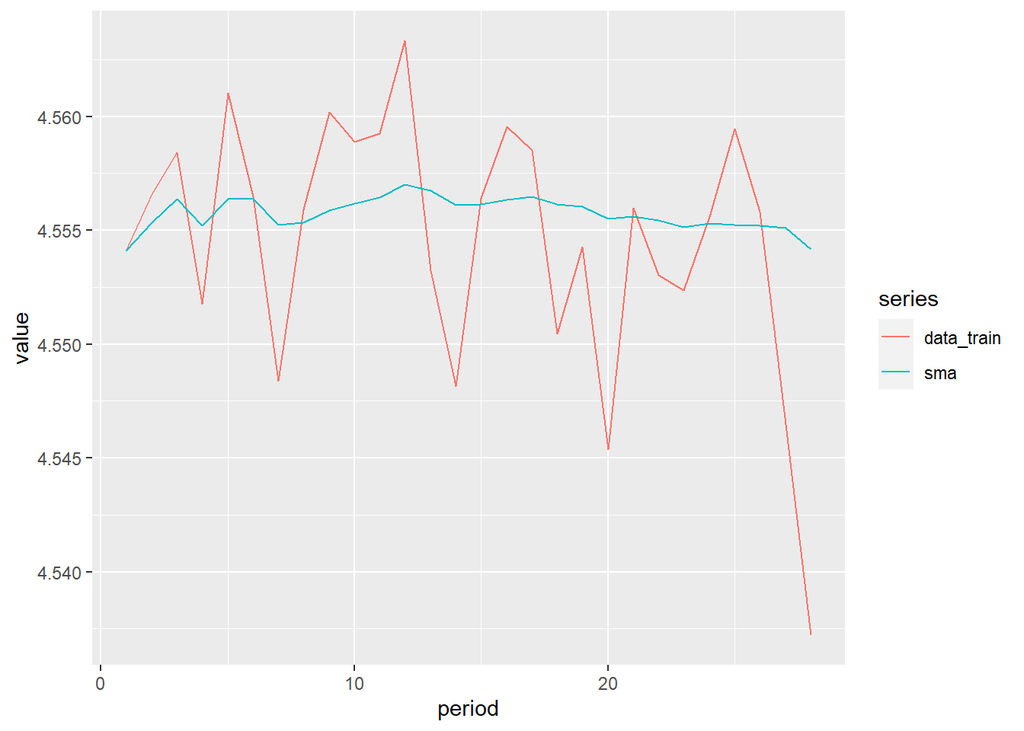

```
##    Point Forecast    Lo 80  Hi 80    Lo 95    Hi 95
## 29       4.554441 4.553683 4.5552 4.553282 4.555601
## [1] "MAE=0.00378019483046302"
## [1] "MAPE=0.000829793106632361"
## [1] "SMAPE=0.000830237541614058"
## [1] "MSE=2.79753747089861e-05"
## [1] "RMSE=0.0052891752390128"
```

### Promedio movil ponderado

#### Promedio Movil ponderado con n=2

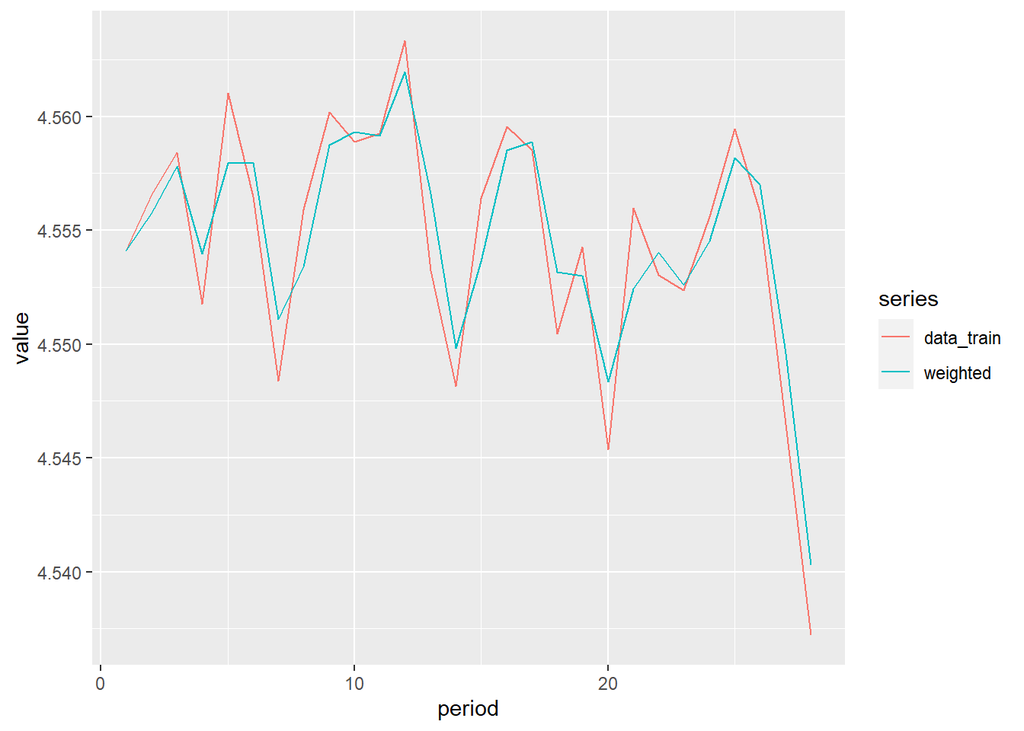

```
##    Point Forecast    Lo 80    Hi 80   Lo 95    Hi 95
## 29       4.540294 4.534812 4.545776 4.53191 4.548679
## [1] "MAE=0.00169365074488919"
## [1] "MAPE=0.000371960535255526"
## [1] "SMAPE=0.0003719781807241"
## [1] "MSE=4.03659520330853e-06"
## [1] "RMSE=0.00200912797086411"
```

#### Promedio Movil ponderado con n=3

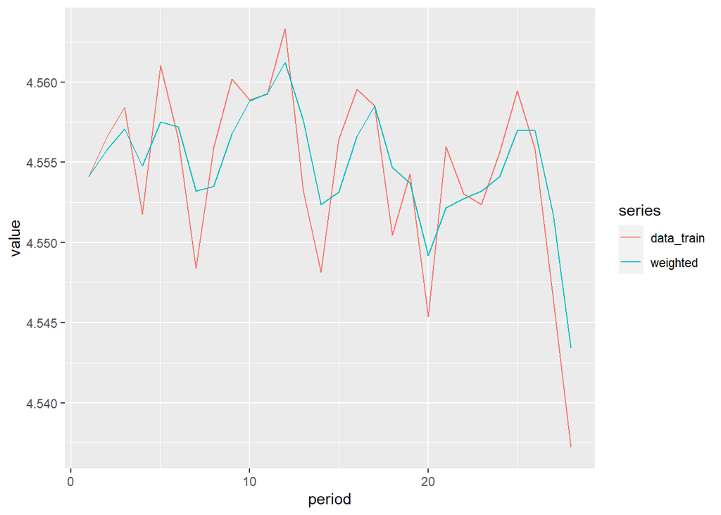

```
##    Point Forecast    Lo 80    Hi 80    Lo 95    Hi 95
## 29       4.543392 4.539329 4.547455 4.537178 4.549606
## [1] "MAE=0.00240015159036542"
## [1] "MAPE=0.00052710176375747"
## [1] "SMAPE=0.000527180166187382"
## [1] "MSE=8.90751184874809e-06"
## [1] "RMSE=0.0029845455012025"
```

#### Promedio Movil ponderado con n=6

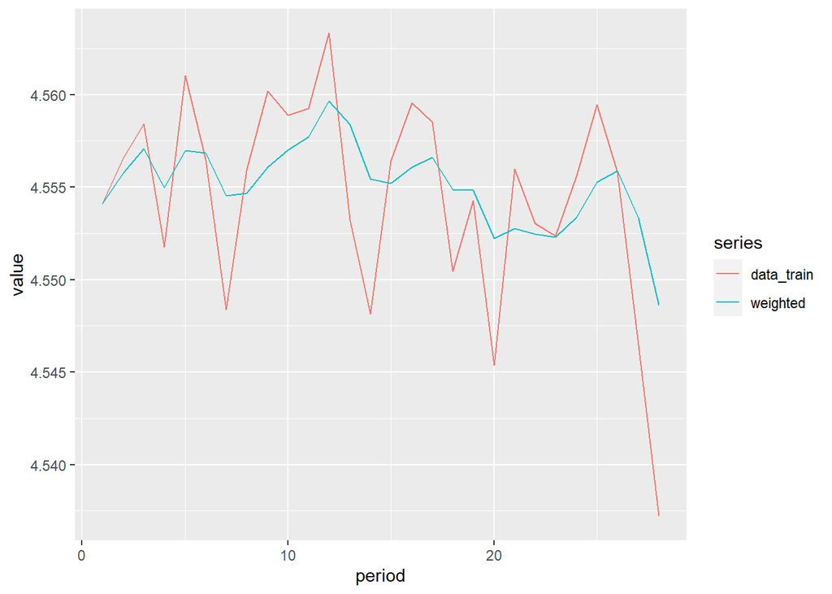

```
##    Point Forecast    Lo 80    Hi 80    Lo 95    Hi 95
## 29       4.548604 4.546343 4.550865 4.545146 4.552062
## [1] "MAE=0.00313998860327753"
## [1] "MAPE=0.000689435470779818"
## [1] "SMAPE=0.000689663844680914"
## [1] "MSE=1.71093996322638e-05"
## [1] "RMSE=0.00413635100448013"
```

#### Promedio Movil ponderado con n=10

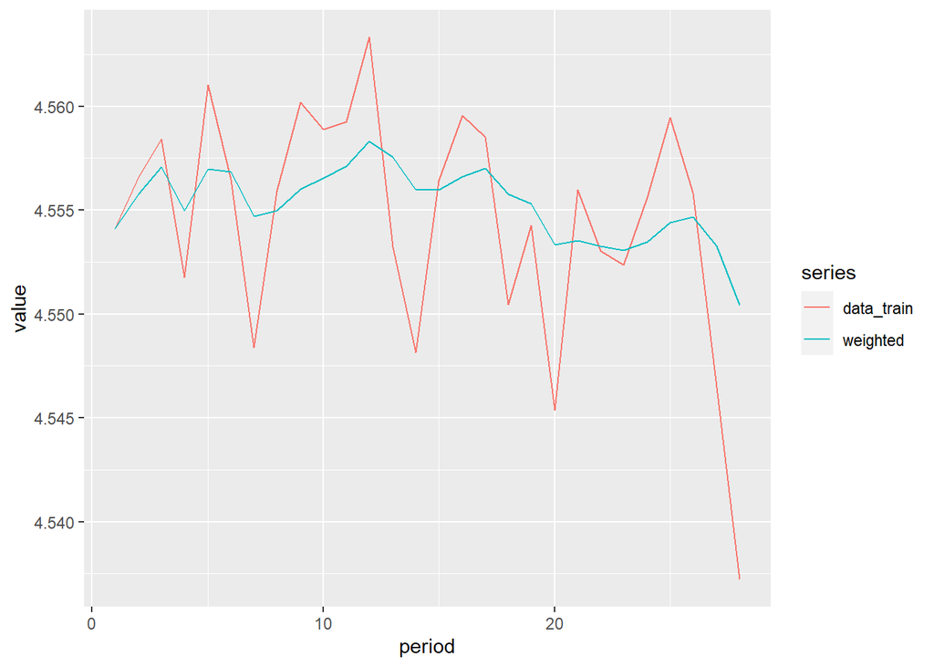

```
##    Point Forecast    Lo 80   Hi 80    Lo 95    Hi 95
## 29       4.550424 4.548809 4.55204 4.547953 4.552895
## [1] "MAE=0.0033480246934871"
## [1] "MAPE=0.000735068579492322"
## [1] "SMAPE=0.000735348393652412"
## [1] "MSE=2.01889640129196e-05"
## [1] "RMSE=0.00449321310566499"
```

### Promedio movil exponencial

#### Promedio movil exponencial con n=2

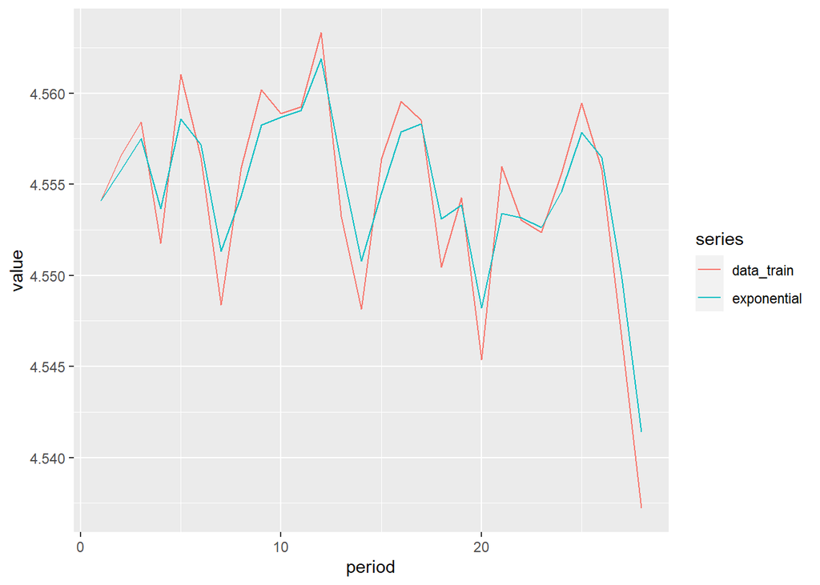

```
##    Point Forecast    Lo 80   Hi 80    Lo 95    Hi 95
## 29       4.541404 4.536259 4.54655 4.533534 4.549274
## [1] "MAE=0.00156940999629951"
## [1] "MAPE=0.000344694733469526"
## [1] "SMAPE=0.00034472934811545"
## [1] "MSE=3.74293076463893e-06"
## [1] "RMSE=0.00193466554335341"
```

#### Promedio movil exponencial con n=3

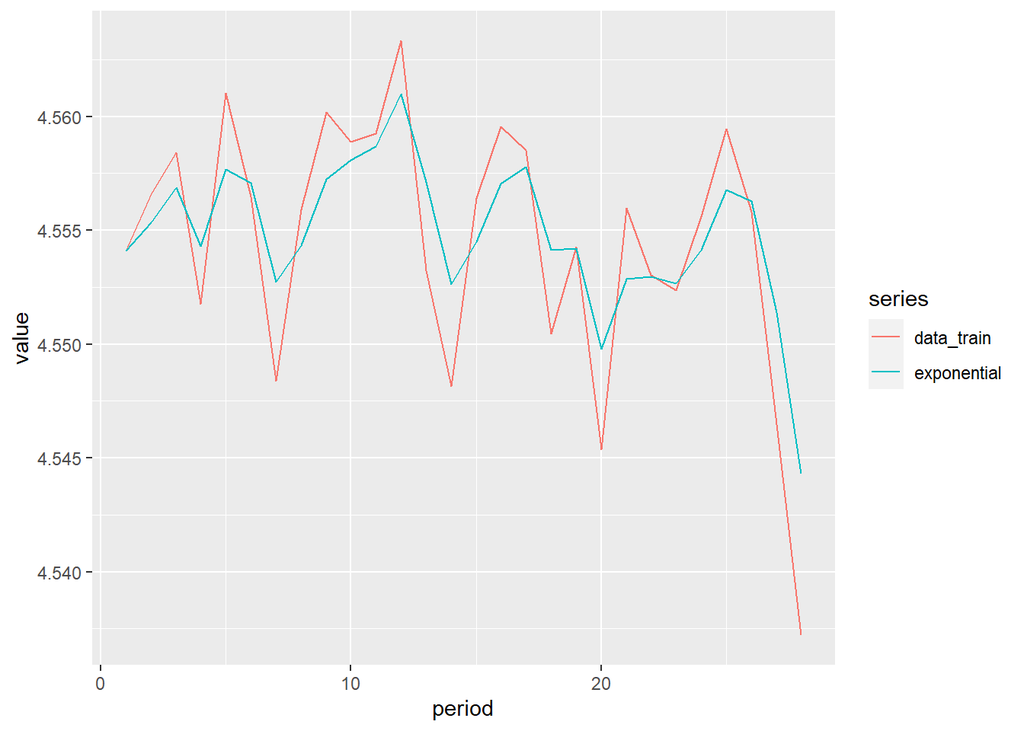

```
##    Point Forecast    Lo 80    Hi 80    Lo 95    Hi 95
## 29       4.544293 4.540477 4.548109 4.538457 4.550129
## [1] "MAE=0.00227359917949437"
## [1] "MAPE=0.000499304790127644"
## [1] "SMAPE=0.000499396936987196"
## [1] "MSE=8.23254534109415e-06"
## [1] "RMSE=0.00286924124832579"
```

### Promedio movil running

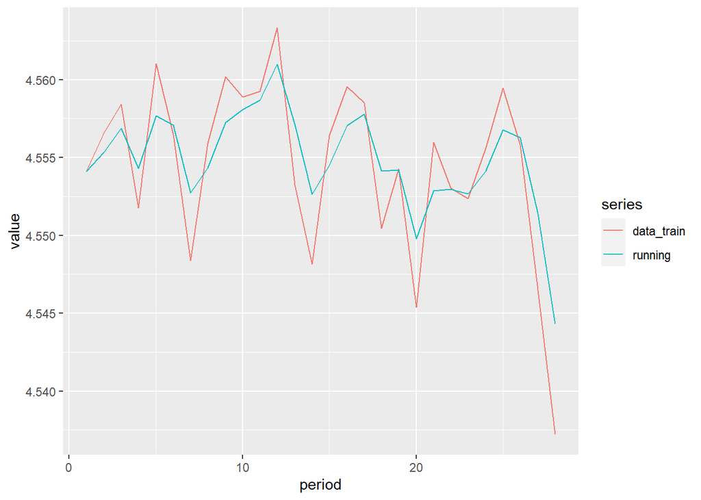

```
##    Point Forecast    Lo 80    Hi 80    Lo 95    Hi 95
## 29       4.544293 4.540477 4.548109 4.538457 4.550129
## [1] "MAE=0.00227359917949437"
## [1] "MAPE=0.000499304790127644"
## [1] "SMAPE=0.000499396936987196"
## [1] "MSE=8.23254534109415e-06"
## [1] "RMSE=0.00286924124832579"
```

### Suavizamiento exponencial simple

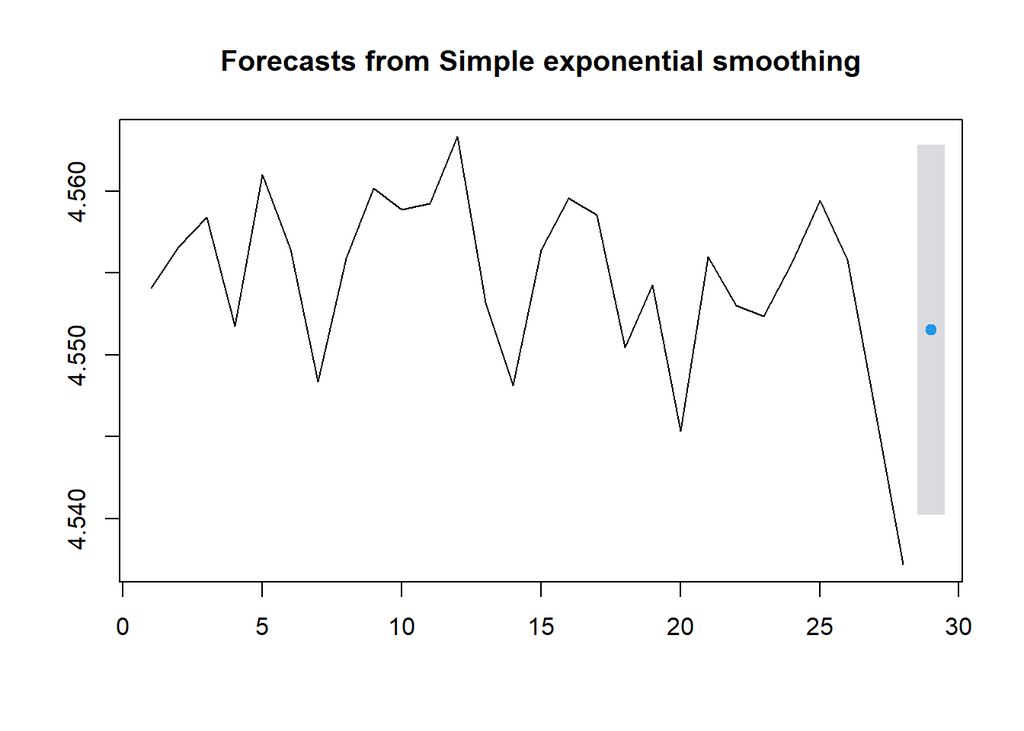

```
##
## Forecast method: Simple exponential smoothing
##
## Model Information:
## Simple exponential smoothing
##
## Call:
##  ses(y = data_train, h = 1, level = c(95, 95), initial = c("optimal"))
##
##   Smoothing parameters:
##     alpha = 0.1396
##
##   Initial states:
##     l = 4.5558
##
##   sigma:  0.0058
##
##       AIC      AICc       BIC
## -191.5679 -190.5679 -187.5712
##
## Error measures:
##                        ME        RMSE         MAE         MPE       MAPE
## Training set -0.001086906 0.005549211 0.004186599 -0.02400717 0.09198853
##                   MASE      ACF1
## Training set 0.7945514 0.1755033
##
## Forecasts:
##    Point Forecast    Lo 95    Hi 95    Lo 95    Hi 95
## 29       4.551535 4.540248 4.562821 4.540248 4.562821
```

### Holt

Queda descartado porque para realizar un pronóstico con esta técnica, toma en cuenta la tendencia explícita de los datos. En nuestro caso no tenemos tendencia.

### Holt Winters

Queda descartado porque para realizar un pronóstico con esta técnica, toma en cuenta la tendencia explicita de los datos. En nuestro caso no tenemos tendencia.

## Conclusión, aplicación y evaluación del modelo analítico

El mejor pronóstico hasta ahora es el promedio móvil exponencial con n=2, debido a que es el que presenta las métricas de error más bajas.

Si analizamos un poco más a fondo podemos observar los siguiente:

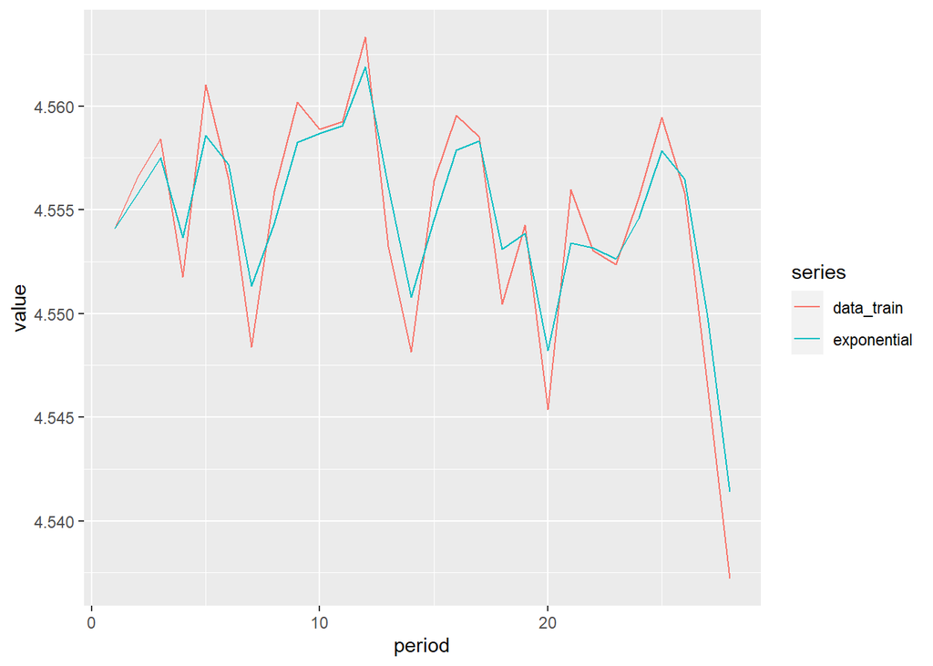

```
##    Point Forecast    Lo 80   Hi 80    Lo 95    Hi 95
## 29       4.541404 4.536259 4.54655 4.533534 4.549274
## [1] "MAE=0.00156940999629951"
## [1] "MAPE=0.000344694733469526"
## [1] "SMAPE=0.00034472934811545"
## [1] "MSE=3.74293076463893e-06"
## [1] "RMSE=0.00193466554335341"
```

Las métricas de error principal son las más pequeñas en comparación con los demás pronósticos.

Para observar mejor la diferencia entre nuestro pronóstico y el dato real, observamos el siguiente gráfico:

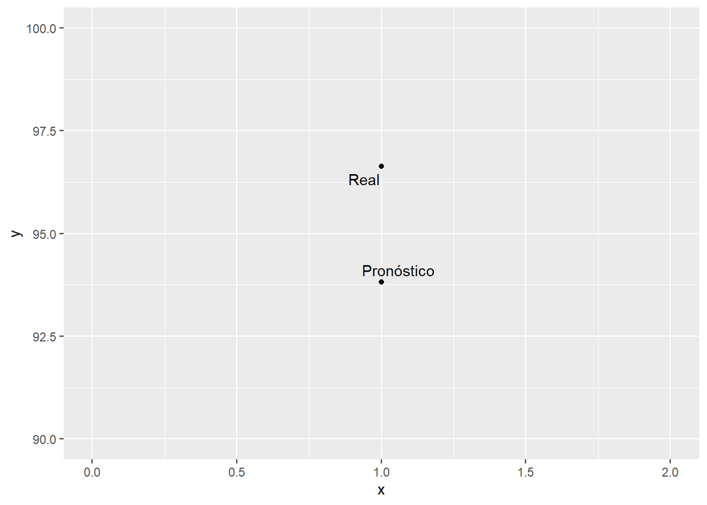

Mientras que nuestro dato real es de 96.63, el pronóstico fue de 93.82; por lo tanto existe una diferencia de 2.8%.

Si alejamos un poco la vista, nos damos cuenta de que la diferencia es realmente poca.

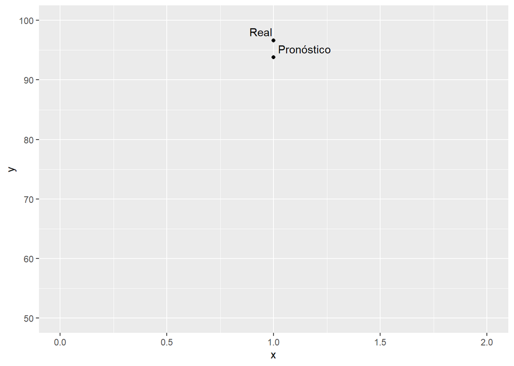

# Redes Neuronales

Otras de las técnicas de pronóstico que se suelen utilizar son las redes neuronales. En este proyecto a manera de profundización, probaremos solamente un par de veces con redes neuronales, con el algoritmo MLP (Multiple Layer Perceptron). Una de las limitaciones en nuestro caso, es que al ser tan pocos datos, fácilmente podemos caer en un caso de sobre estimación al estar usando algoritmos más complejos.

```
## MLP fit with 5 hidden nodes and 20 repetitions.
## Univariate lags: (1)
## Forecast combined using the median operator.
## MSE: 0.
```

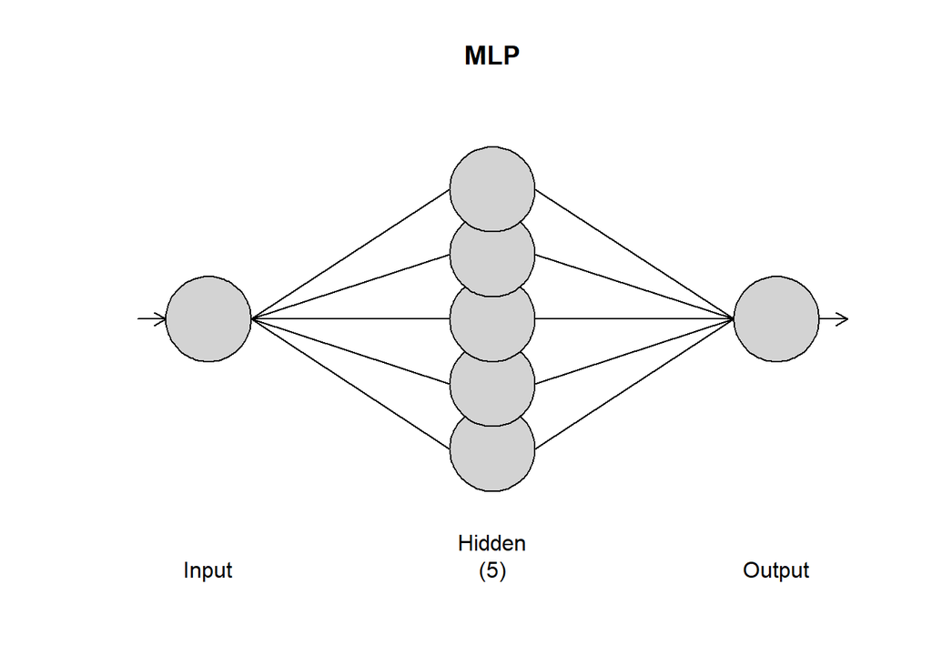

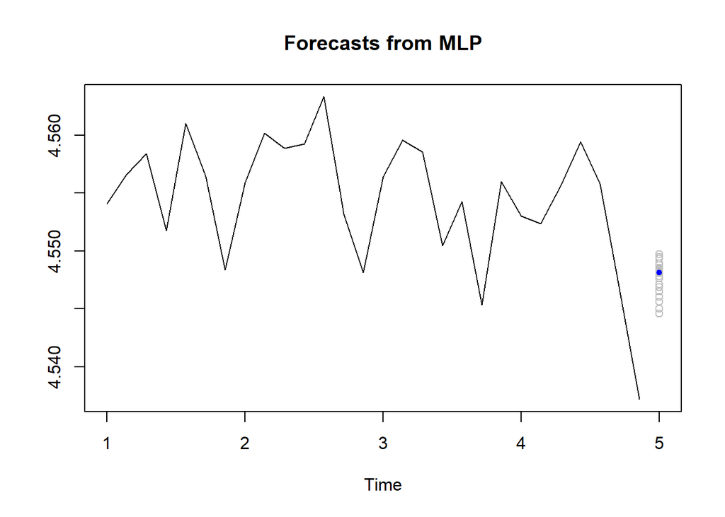

```
##   Point Forecast
## 5        4.54814
```

En este caso, nuestro error MSE es de:

Por lo tanto, comparando el punto especifico que estamos prediciendo:

- Real: 96.6301259
- MLP : 94.44596
- Promedio Móvil Exponencial: 93.8224344

De acuerdo a los datos, el método MLP nos ofrece una mejor precisión en cuanto al pronóstico, sin embargo por la limitación en la cantidad de los datos antes mencionado, seguiremos concluyendo que por ahora, el método de pronostico de promedio móvil exponencial, es el mejor.

# Clustering

Para realizar el análisis con clustering, voy a utilizar un data set que contiene todo los intab promedio por semana de cada casa. Hare un filtrado de la información para agruparla por cada casa.

|  | mean_INTAB | meanS1 | meanS2 | meanS3 | meanV |
| --- | --- | --- | --- | --- | --- |
| 100 | 99.01478 | 0.00000000 | 0.03448276 | 0.00000000 | 0.00000000 |
| 163 | 99.50739 | 0.03448276 | 0.00000000 | 0.00000000 | 0.00000000 |
| 167 | 93.10345 | 0.10344828 | 0.06896552 | 0.03448276 | 0.00000000 |
| 168 | 98.02956 | 0.00000000 | 0.00000000 | 0.03448276 | 0.00000000 |
| 21100004 | 98.02956 | 0.00000000 | 0.00000000 | 0.03448276 | 0.03448276 |
| 21100217 | 69.45813 | 0.10344828 | 0.06896552 | 0.37931034 | 0.00000000 |

En la anterior tabla, la primera columna representa el ID de cada casa y despues esta el INTAB promedio por domicilio. Las columnas siguientes representan anotaciones de los dueños de la base de datos. Concretamente cada una indican anotaciones númericas y bien definidas que los responsables hacen para identificar cuando una casa tuvo algún incoveniente con su INTAB.

De esa manera, si una casa tuvo problemas en periodos consecutivos con su INTAB; tendrá anotaciones en S1,S2,S3,V. Sin embargo si un domicilio solamente tuvo incoveniente en dos periodos; entonces tendrá anotación en S1, S2. De esa manera, las columnas de S y V nos puede brindar información sobre el comportamiento del INTAB de las casas.

Para iniciar con el analisis de clustering, verificaré el numero de clusters que se ajusta mejor a mis datos. Utilizaré los métodos wss, silueta y el de gap_stat los cuales son los más usados para determinar el numero de clusters.

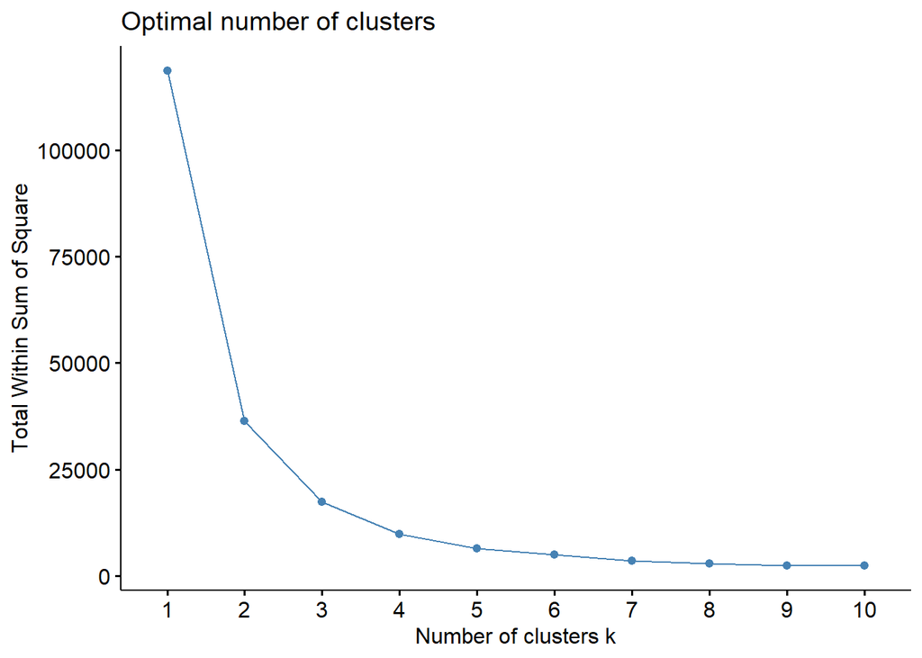

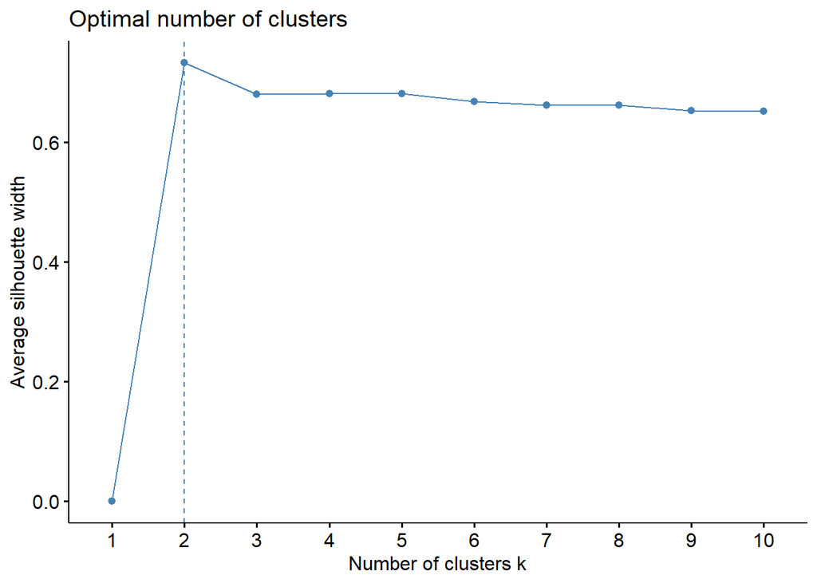

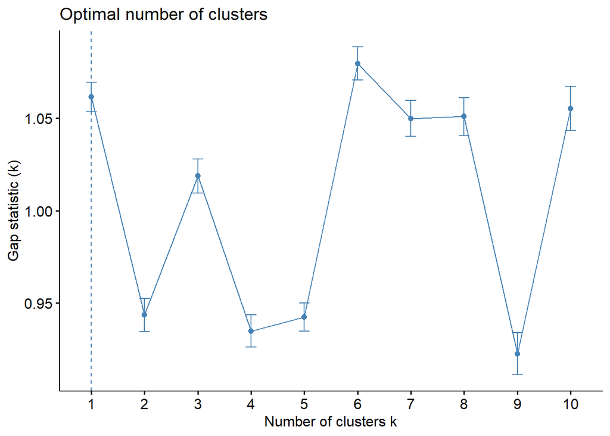

De las anteriores visualizaciones puedo observar que el metodo wss me sugiere 2 clusters al igual que el de la silueta; sin embargo el gap_stat solamente me sugiere un cluster.

Debido a que no tengo un número de clusters especificos con los que yo infiera que puedo tener mejores conclusiones, porbaré con 2,3 y 4 clusters para ver cual se ajusta de mejor manera.

En este proyecto, me limitare a utilizar la distancia euclidiana para todos los casos.

## Dos clusters

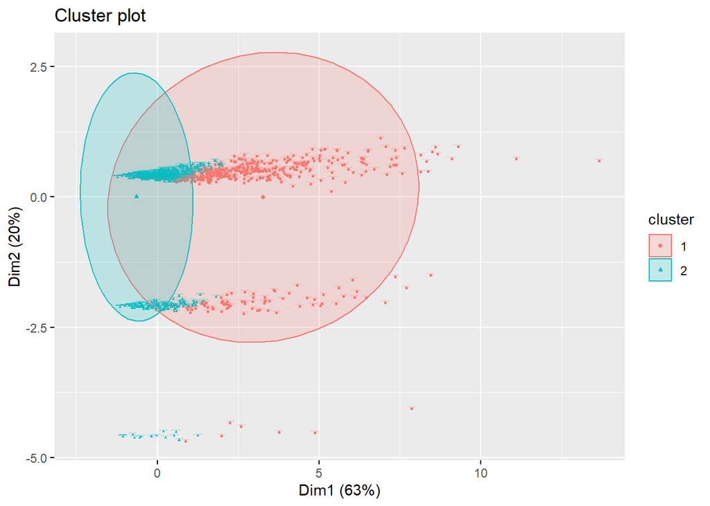

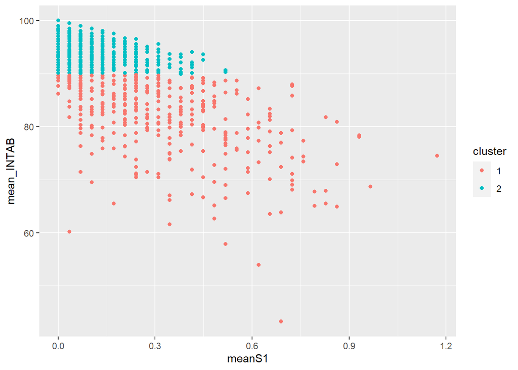

En la primera gráfica observamos la disposición general de los datos, y como es que se agrupan cada una en su cluser. El cluster 2 (color azul) representa los domcilios con INTAB más alto; mientras que el cluster 1 (color rojo) representa los domicilios con un INTAB más bajo.

En la segunda gráfica podemos observar mejor como es que se distribuyen los clusters. En nuestro eje **y** tenemos el INTAB, por lo tanto se nota una clara diferencia entre los docimilios que están por arriba del 90% aprox y los que están por debajo.

Para ser más precisos:

```r
k2$centers[,1]
```

```
##        1        2
## 82.04513 97.67043
```

```r
k2$size
```

```
## [1]  402 2062
```

El cluster 1 tiene su centro en el INTAB 82.04513, mientras que el cluster 2 tiene su centro en el INTAB 97.67043. El cluster 1 tiene un total de 402 domicilios y el cluster 2 tiene un total de 2,062 domicilios.

Debido a que me parece muy extrmista clasificar como “malos” a los domicilios que tienen un INTAB de 82%, probaré con 3 y 4 clusters esperando tener una mejor clasificación para mis datos.

Por último, para dos clusters, ofrezco esta visualización la cual nos permite ver las diferencias entre clusters. Para este caso, lo que diferencia a un cluster de otro; es el INTAB. Debido a que las demás columnas (meanS1, meanV, etc) no tienen una diferencia significativa entre clusters.

```
## No summary function supplied, defaulting to `mean_se()`
```

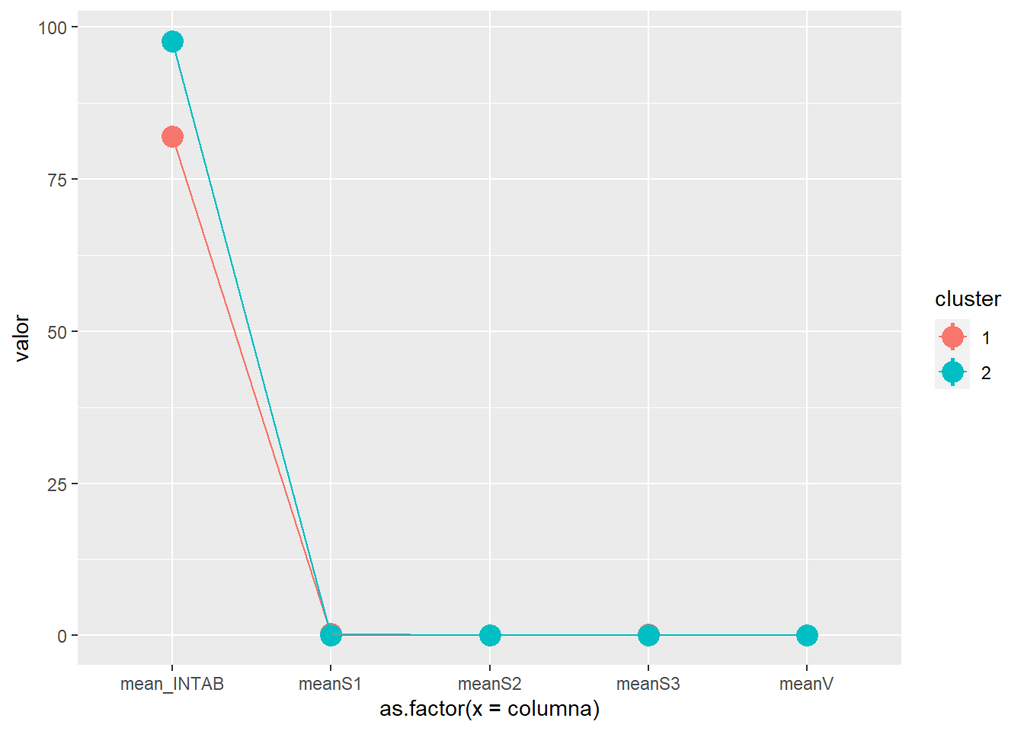

## Tres Clusters

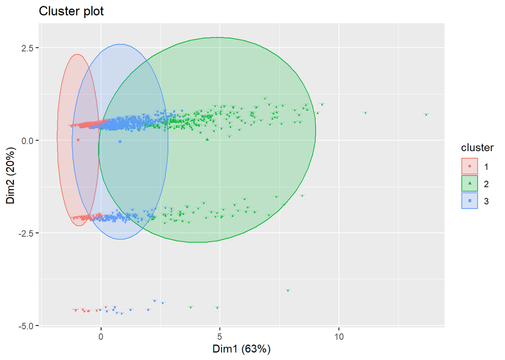

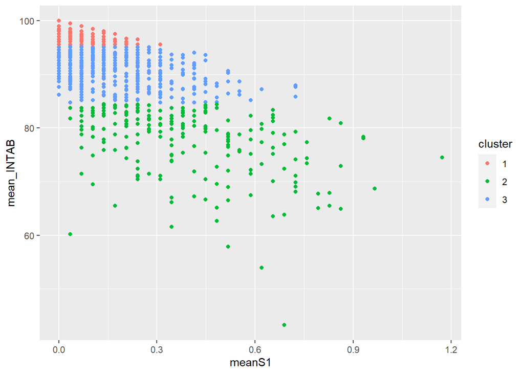

A partir de estos tres grupos podria pensar en una clasificación como:

- INTABS Altos
- INTABS Medios
- INTABS Bajos

En la segunda gráfica podemos observar mejor como es que se distribuyen los clusters. El cluster de INTABS altos pareciera que esta por arriba de los 95, el cluster de INTABS Medios esta entre 85-95 y el ultimo cluster esta por abajo de los 85.

```r
k3$centers[,1]
```

```
##        1        2        3
## 99.02821 77.57356 91.65650
```

```r
k3$size
```

```
## [1] 1586  224  654
```

El cluster de INTABS altos contiene 1,586 domicilios; el cluster de INTABS medio contiene 654 y el cluster de INTABS bajo contiene 224.

```
## No summary function supplied, defaulting to `mean_se()`
```

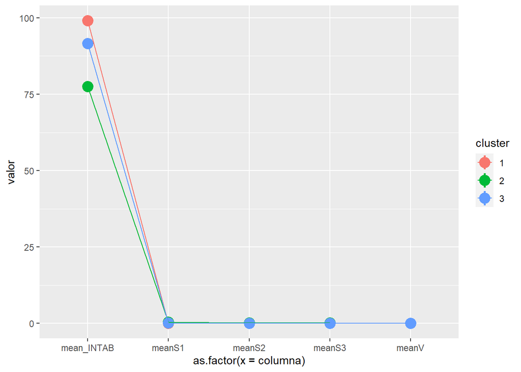

Finalmente al igual que con 2 clusters, la diferencia significativa entre los clusters se encuentra en el INTAB y no en las observaciones de S1, S2, S3, V.

## Cuatro Clusters

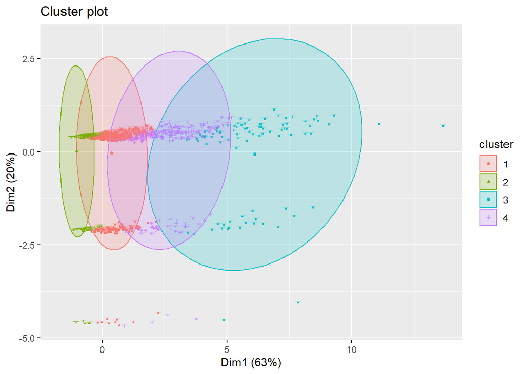

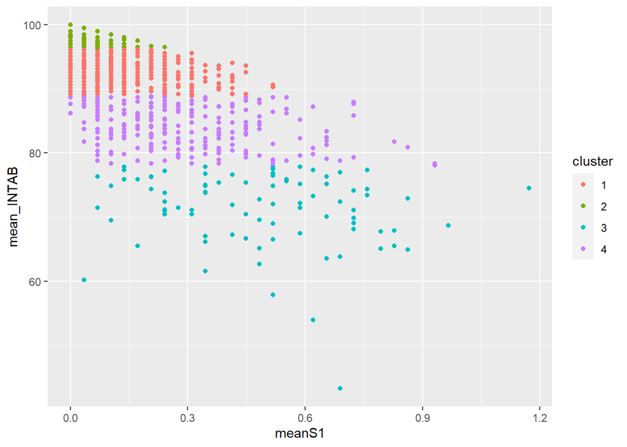

En la priemera gráfica me parece que con cuatro clusters ya ni siquiera se alcanza a visualizar bien la diferencia de los clusters. Sin embargo el cluster azul (el del extremo derecho) pareciera mucho más disperso; a diferencia del cluster verde (el del extremo izquierdo) el cual se ve muy compacto.

En la segunda gráfica podemos observar mejor la distribución de los clusters. Esta distribución me parece más adecuada debido a que los INTABS más bajos y dispersos quedan agrupados (cluster 3 de color azul)

```r
k4$centers[,1]
```

```
##        1        2        3        4
## 93.37847 99.28550 71.38429 84.34858
```

```r
k4$size
```

```
## [1]  639 1468   89  268
```

El cluster de INTAB alto contiene 1,468, el cluster de INTAB normal contiene 639, el cluster de INTAB regular contiene 268 y el cluster de INTAB bajo contiene 89 domicilios.

Me parece más adecuado esta clasificación debido a que se puede pasar un informe detallada de ese último cluster para darle un seguimiento exhaustivo a esos hogares y poder mejorar sus intabs, más adelante se podria observar si el domicilio cambia de cluster en unos meses más.

```
## No summary function supplied, defaulting to `mean_se()`
```

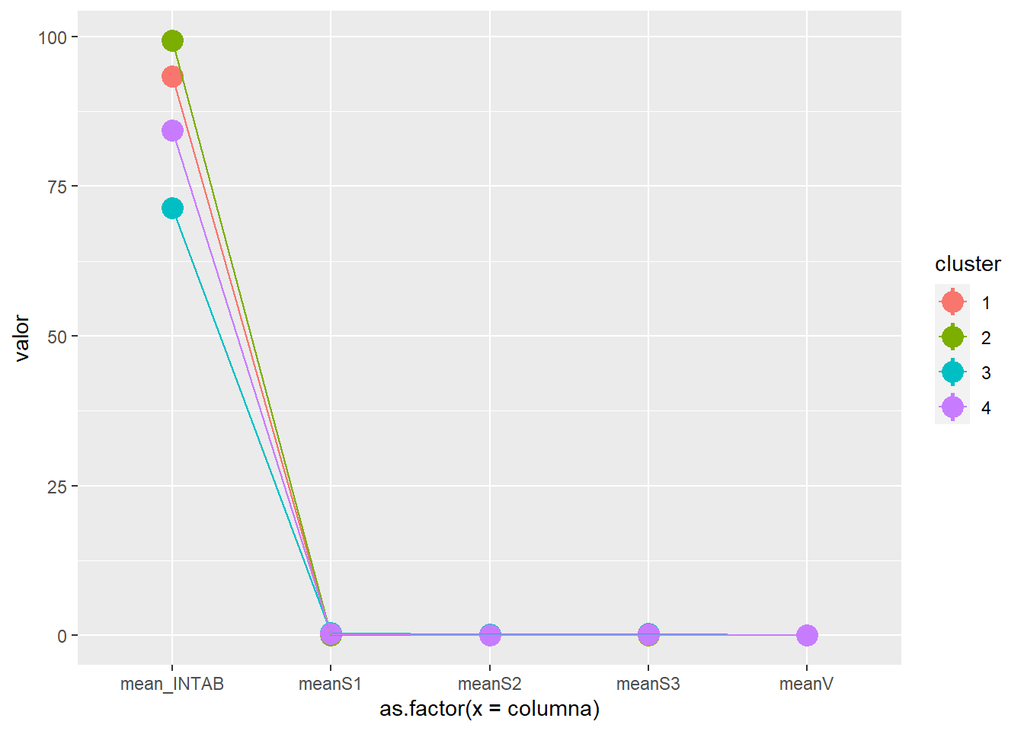

Nuevamente la diferencia representativa se encuentra en el INTAB para todos los clusters.

# Conclusiones

El mejor pronóstico lo ofrece Promedio Movil exponencial con n=2

A manera de ejemplo, a pesar de que solamente se pronosticara el siguiente periodo, así se veria el pronóstico de intabs para el siguiente mes (4 periodos):

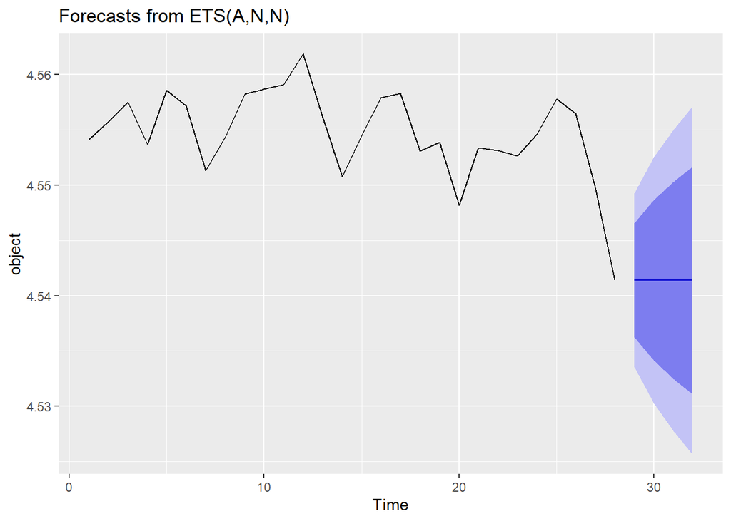

La mejor clasificación es con K = 4 debido a que se clasifica de manera más apropiada para nuestro caso. De esta manera tenemos los grupos como:

- INTABS ALTOS
- INTABS BUENOS
- INTABS REGULARES
- INTABS BAJOS

Pasaré la lista con los ID´s de los domicilios clasificados dentro del cluster de INTABS BAJOS (89 domicilios) para que el equipo de NIELSEN pueda realizar un seguimiento exhaustivo y tratar de solucionar el problema. En unos meses más podré corrobar si el domicilio se movio de cluster al de regular, bueno o alto. De igual manera informare de todos los ID´S con su respectiva clasificación.

Más adelante, cuando se tengan más datos, realizaré otra evaluación de modelos para asegurarme de estar ocupando la mejor técnica de pronóstico.

# Beneficios

El mayor beneficio de este proyecto es tener el pronóstico del INTAB, el cual ayuda principalmente a evitar algún tipo de INTAB bajo que repercuta en la entrega final al usuario lo cual supondria una mala reputación con el cliente. Sabiendo que el pronóstico de la siguiente semana es bajo, el equipo de NIELSEN puede revisar la raíz del problema (revisando más detalladamente los domicilios) y solucionar el potencial problema.

Esa revisión detallada se puede hacer más fácil si se tiene bien identificado el grupo de domicilios que tienen un INTAB bajo dentro de nuestro cluster. Así mismo, gracias a la clasificación por clusters, se puede hacer un seguimiento exhaustivo de los domicilios clasificados en el cluster de INTABS bajos para encontrar la manera de mejorar sus INTABS; ya sea llamando al domicilio o agendando la revisión de un técnico, y que de esa manera mejore su INTAB promedio y se mueva de cluster. La misma metodologia la recomiendo para el cluster de INTABS regulares. Mientras que para los útlimos dos clusters que son los de mejor INTAB, solamente sería bueno tenerlos identificados y saber cuantos de ellos se encuentran en esos clusters.